# Section 3 — Univariate and Multivariate Normal Models

STA5001 R Computational Companion

STA5001 Bayesian & Computational Statistics

Work through the examples in order. Section numbers follow the STA5001 lecture notes, which develop the models and algorithms used here. Open `section-03.Rmd` in RStudio and choose **Knit** to reproduce the outputs. Section 3.3 also uses BayesComp for the constructed school data and the shared Gaussian and quadrature calculations. The package also supplies figures from the lecture notes. Install it with `remotes::install_github("sj156/BayesComp", subdir = "BayesComp")`.

# Section 3.1 — Paired differences and exact Gaussian inference

**Concept.** Pairing removes each subject’s common level by working with within-subject differences. Prediction for another subject then includes variation between individual differences.

## Data and inferential targets

**Example.** `datasets::sleep` compares two drugs within each of ten subjects. The printed differences below are drug 2 minus drug 1, in hours. We compare uncertainty about the population mean difference with prediction for a new subject. The Gaussian model assumes independent subjects and normally distributed differences; these assumptions need scientific assessment.

Reshape the original data by subject and check the printed differences.

```r
sleep_differences <- c(1.2, 2.4, 1.3, 1.3, 0, 1, 1.8, 0.8, 4.6, 1.4)
sleep_wide <- reshape(datasets::sleep, idvar="ID", timevar="group",
                      direction="wide")
stopifnot(max(abs(sleep_differences -
                 (sleep_wide$extra.2 - sleep_wide$extra.1))) < 1e-12)
knitr::kable(data.frame(subject=1:10, difference_hours=sleep_differences))
```

| subject | difference_hours |
| --- | --- |
| 1 | 1.2 |
| 2 | 2.4 |
| 3 | 1.3 |
| 4 | 1.3 |
| 5 | 0.0 |
| 6 | 1.0 |
| 7 | 1.8 |
| 8 | 0.8 |
| 9 | 4.6 |
| 10 | 1.4 |

Use the prior $\sigma^2\sim\operatorname{InvGam}(a_0,b_0)$, $\delta\mid\sigma^2\sim N(m_0,\sigma^2/k_0)$, with $(m_0,k_0,a_0,b_0)=(0,1,2,2)$. Here `b0` is the inverse-gamma scale, and the rate of the gamma law for precision.

Update the normal–inverse-gamma parameters from the sample size, mean, and centered sum of squares. The two Student distributions share a location and degrees of freedom. Their scales differ by the individual variation.

```r
nig_update <- function(x, m0=0, k0=1, a0=2, b0=2) {
  stopifnot(length(x)>0, all(is.finite(x)), k0>0, a0>0, b0>0)
  n <- length(x); xbar <- mean(x); q <- sum((x-xbar)^2)
  kn <- k0+n
  list(n=n, xbar=xbar, q=q, kn=kn, mn=(k0*m0+n*xbar)/kn,
       an=a0+n/2, bn=b0+.5*(q+k0*n/kn*(xbar-m0)^2))
}
sleep_post <- nig_update(sleep_differences)
unlist(sleep_post)
```

```
##         n      xbar         q        kn        mn        an        bn
## 10.000000  1.580000 13.616000 11.000000  1.436364  7.000000  9.942727
```

```r
sleep_df <- 2*sleep_post$an
sleep_mean_scale <- sqrt(sleep_post$bn/(sleep_post$an*sleep_post$kn))
sleep_pred_scale <- sqrt(sleep_post$bn/sleep_post$an*(1+1/sleep_post$kn))
sleep_exact <- c(mean_positive=pt(sleep_post$mn/sleep_mean_scale,sleep_df),
                future_positive=pt(sleep_post$mn/sleep_pred_scale,sleep_df))
sleep_exact
```

```
##   mean_positive future_positive
##       0.9993384       0.8660691
```

```r
sleep_post$mn + qt(c(.025,.975),sleep_df)*sleep_mean_scale
```

```
## [1] 0.6656527 2.2070745
```

```r
stopifnot(abs(sleep_post$xbar-1.58)<1e-12,
          abs(sleep_post$q-13.616)<1e-10)
```

The mean difference has about 99.93% posterior probability of being positive, while a new subject has about 86.61% predictive probability of a positive difference. The mean’s 95% credible interval is approximately [0.666, 2.207] hours. These are different inferential questions.

## Composition sampling and accuracy

This implements the composition algorithm in Subsection 3.1. Each mean draw uses the variance drawn in the same repetition. Entire repetitions are independent; their two parameter coordinates need not be independent.

```r
set.seed(3101)
sleep_r <- 50000
sleep_sigma2 <- 1/rgamma(sleep_r, shape=sleep_post$an, rate=sleep_post$bn)
sleep_delta <- rnorm(sleep_r, sleep_post$mn, sqrt(sleep_sigma2/sleep_post$kn))
sleep_future <- rnorm(sleep_r, sleep_delta, sqrt(sleep_sigma2))
sleep_indicators <- cbind(mean_positive=sleep_delta>0,
                          future_positive=sleep_future>0)
sleep_est <- colMeans(sleep_indicators)
sleep_mcse <- sqrt(sleep_est*(1-sleep_est)/sleep_r)
knitr::kable(data.frame(target=names(sleep_exact), exact=sleep_exact,
                       simulation=sleep_est, MCSE=sleep_mcse,
                       error_in_MCSE=(sleep_est-sleep_exact)/sleep_mcse),digits=5)
```

|  | target | exact | simulation | MCSE | error_in_MCSE |
| --- | --- | --- | --- | --- | --- |
| mean_positive | mean_positive | 0.99934 | 0.99920 | 0.00013 | -1.09431 |
| future_positive | future_positive | 0.86607 | 0.86476 | 0.00153 | -0.85594 |

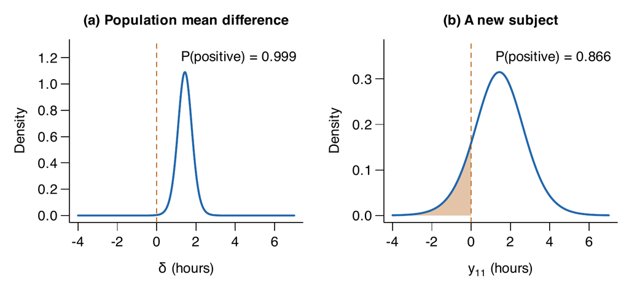

Lecture notes, Section 3.1. Shaded tails show the probabilities of a nonpositive difference.

```r
stopifnot(all(abs(sleep_est-sleep_exact)<6*sleep_mcse+1/sleep_r))
```

**Extension.** Refit with `k0=4`, then with `m0=1.58`, leaving the other hyperparameters fixed. Compare the change in `bn` and both probabilities. Treat the latter as a sensitivity calculation, not independent prior evidence learned before these same data were observed.

# Section 3.2 — Equal prior moments, different posterior conclusions

**Concept.** A prior’s mean and variance can leave important features of its shape unspecified. In Gaussian denoising, separated prior masses and a continuous prior can give very different posterior adjustments.

**Example.** Compare a $N(0,4)$ prior with a prior putting probability one-half on each of $-2$ and $2$, under $Y\mid\mu\sim N(\mu,1)$. Both priors have mean zero and variance four. The discrete prior’s posterior can be computed exactly by Bayes’ rule; no Monte Carlo is needed.

Convert the log odds for the two signals to a probability and calculate its implied posterior moments. Differentiate the marginal density to check those moments using Tweedie’s formula.

```r
tweedie_y <- seq(-4,4,length.out=801)
tweedie_weight <- plogis(4*tweedie_y)
tweedie_mean <- 4*tweedie_weight-2
tweedie_var <- 16*tweedie_weight*(1-tweedie_weight)
stopifnot(max(abs(tweedie_mean-2*tanh(2*tweedie_y)))<1e-12)
# Check Tweedie's derivatives directly from the two Gaussian components.
tweedie_marginal <- .5*dnorm(tweedie_y+2)+.5*dnorm(tweedie_y-2)
tweedie_first <- -.5*(tweedie_y+2)*dnorm(tweedie_y+2) -
                  .5*(tweedie_y-2)*dnorm(tweedie_y-2)
tweedie_second <- .5*((tweedie_y+2)^2-1)*dnorm(tweedie_y+2) +
                   .5*((tweedie_y-2)^2-1)*dnorm(tweedie_y-2)
tweedie_score <- tweedie_first/tweedie_marginal
tweedie_curvature <- tweedie_second/tweedie_marginal-tweedie_score^2
stopifnot(max(abs(tweedie_y+tweedie_score-tweedie_mean))<1e-10,
          max(abs(1+tweedie_curvature-tweedie_var))<1e-10)
knitr::kable(data.frame(y=c(0,1),
  normal_mean=.8*c(0,1), two_point_mean=2*tanh(2*c(0,1)),
  normal_variance=.8, two_point_variance=4*(1-tanh(2*c(0,1))^2)),digits=4)
```

| y | normal_mean | two_point_mean | normal_variance | two_point_variance |
| --- | --- | --- | --- | --- |
| 0 | 0.0 | 0.0000 | 0.8 | 4.0000 |
| 1 | 0.8 | 1.9281 | 0.8 | 0.2826 |

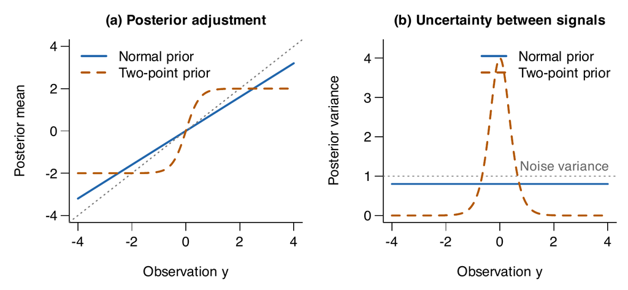

Lecture notes, Section 3.2. The two prior shapes give very different posterior variances near zero.

At zero, both posterior means are zero, but the discrete prior leaves equal probability on two separated signals and posterior variance four. At one, its posterior mean is about 1.928: the adjustment goes toward the nearby signal, rather than toward the prior mean. A denoised mean need not itself be a plausible signal under a discrete prior.

**Extension.** Replace the equal masses by probabilities 0.2 and 0.8. Derive the new log posterior odds and plot the resulting mean and variance. Locate the observation at which the two signals are equally probable.

# Section 3.3 — Hierarchical Gaussian school means

**Concept.** Partial pooling uses a common center and between-school scale to share information across schools. The data inform both quantities, and integrating over them preserves uncertainty in school effects.

## Question, data, and model

**Example.** Use six constructed schools with sample sizes from 5 to 160. We estimate their means, compare schools, and predict for a new school or individual student.

| School | Students sampled | Observed mean | Sampling variance of the mean |
| --- | --- | --- | --- |
| A | 5 | 58 | 20 |
| B | 10 | 82 | 10 |
| C | 20 | 62 | 5 |
| D | 40 | 78 | 2.5 |
| E | 80 | 68 | 1.25 |
| F | 160 | 74 | 0.625 |

Use $Y_j \mid \theta_j \sim N(\theta_j,100/n_j)$, $\theta_j \mid \eta,\tau \sim N(\eta,\tau^2)$, $\eta \sim N(70,100)$, and $\tau^2 \sim \operatorname{InvGam}(3,200)$, independently a priori. Here $N(m,v)$ uses variance $v$, and the inverse-gamma density is proportional to $u^{-a-1}\exp(-b/u)$ for $u>0$. The known within-school variance is 100. The displayed summaries suffice for this likelihood; individual scores would not add information about school means under that assumption.

## 1. Conditional Gaussian calculations

At each scale $\tau$, Gaussian updating gives the posterior mean and variance of the shared center. Write $V_j=\tau^2+s_j^2$, where $s_j^2=100/n_j$. The center’s posterior variance is $v=(1/v_0+\sum_j 1/V_j)^{-1}$ and its mean is $m=v(m_0/v_0+\sum_j y_j/V_j)$. The weight on school $j$’s observed mean is $w_j=\tau^2/V_j$. For one value of $\tau$, the steps are

```r
library(BayesComp)
data("school_means", package = "BayesComp")

y <- school_means$observed_mean
n <- school_means$n
schools <- school_means$school
J <- length(y)
sigma2 <- 100
s2 <- sigma2 / n
m0 <- 70
v0 <- 100
a0 <- 3
b0 <- 200

tau_example <- 8
V <- tau_example^2 + s2
v <- 1 / (1 / v0 + sum(1 / V))
m <- v * (m0 / v0 + sum(y / V))
w <- tau_example^2 / V
m_school <- w * y + (1 - w) * m
d <- w * s2
var_school <- d + (1 - w)^2 * v

check <- school_means_conditional(tau_example, y, s2, m0, v0)
stopifnot(isTRUE(all.equal(m_school, drop(check$m_school))),
          isTRUE(all.equal(var_school, drop(check$var))))
data.frame(school = schools, weight_on_data = w, mean = m_school,
           sd = sqrt(var_school))
```

```
##   school weight_on_data     mean        sd
## 1      A      0.7619048 60.99368 3.9787136
## 2      B      0.8648649 80.45587 2.9731083
## 3      C      0.9275362 62.62127 2.1662232
## 4      D      0.9624060 77.72081 1.5558842
## 5      E      0.9808429 68.04930 1.1090025
## 6      F      0.9903288 73.96686 0.7873578
```

The package applies the same update to a vector of scales. Its matrices have one row per scale and one column per school. The conditional variance `d` is given both the center and scale. The variance `var` integrates out the center and therefore includes its uncertainty.

## 2. Marginal scale posterior

Integrate out the school means and center analytically, leaving one positive scale. Define the prior on $\tau$ explicitly. The change of variables from $\tau^2$ to $\tau$ contributes the Jacobian $2\tau$. The package combines this prior with the marginal likelihood and applies the trapezoidal rule with spacing 0.005 and upper limit 120. The normalized quadrature weights are used for posterior summaries and the cumulative integral for simulation.

```r
log_prior <- function(tau, shape = a0, scale = b0) {
  ans <- rep(-Inf, length(tau))
  positive <- tau > 0
  t <- tau[positive]
  ans[positive] <- log(2) + shape * log(scale) - lgamma(shape) -
    (2 * shape + 1) * log(t) - scale / t^2
  ans
}

g <- school_means_grid(y, s2, m0, v0, log_prior)
```

## 3. Summaries and numerical accuracy

A school’s marginal posterior is a mixture of normals across the scale grid. Invert that mixture CDF for credible intervals. The root bracket [0,140] contains the requested quantiles for these data; adapt it if the score scale changes. Refine grid spacing and extend the range separately. The assertions below stop rendering if the stated tolerances fail.

```r
means <- function(g) colSums(g$conditional$m_school*g$weights)
qmix <- function(j, prob) {
  uniroot(function(x) {
    sum(g$weights*pnorm(x, g$conditional$m_school[,j], sqrt(g$conditional$var[,j]))) - prob
  }, c(0,140))$root
}
lo <- sapply(1:J, qmix, prob=.025)
hi <- sapply(1:J, qmix, prob=.975)
cbind(n=n, observed=y, posterior=means(g), lo=lo, hi=hi)
```

```
##        n observed posterior       lo       hi
## [1,]   5       58  60.80840 52.61710 68.79856
## [2,]  10       82  80.54363 74.63024 86.51882
## [3,]  20       62  62.59242 58.30336 66.86619
## [4,]  40       78  77.73405 74.67650 80.79527
## [5,]  80       68  68.04768 65.87258 70.22230
## [6,] 160       74  73.96843 72.42482 75.51216
```

```r
contrast <- function(g) {
  delta <- g$conditional$m_school[,2] - g$conditional$m_school[,1]
  v <- g$conditional$d[,1] + g$conditional$d[,2] +
    (g$conditional$w[,1]-g$conditional$w[,2])^2*g$conditional$v
  sum(g$weights*pnorm((delta-5)/sqrt(v)))
}
g_fine <- school_means_grid(y, s2, m0, v0, log_prior, n_grid = 48001L)
g_wide <- school_means_grid(y, s2, m0, v0, log_prior,
                            upper = 240, n_grid = 48001L)
stopifnot(max(abs(means(g)-means(g_fine))) < 1e-6,
          max(abs(means(g)-means(g_wide))) < 1e-6,
          abs(contrast(g)-contrast(g_fine)) < 1e-6,
          abs(contrast(g)-contrast(g_wide)) < 1e-6)
f <- function(t) {
  exp(log_prior(t) + school_means_log_likelihood(t, y, s2, m0, v0) -
        g$log_shift)
}
tailmass <- integrate(f, 120, Inf)$value /
            integrate(f, 0, Inf)$value
stopifnot(tailmass < 1e-8)
c(E_tau=sum(g$tau*g$weights), contrast=contrast(g), tail=tailmass)
```

```
##        E_tau     contrast         tail
## 8.832397e+00 9.982597e-01 1.835522e-12
```

School means and 95% equal-tailed credible intervals

| School | n | Observed | Posterior | Lower | Upper |
| --- | --- | --- | --- | --- | --- |
| A | 5 | 58 | 60.81 | 52.62 | 68.80 |
| B | 10 | 82 | 80.54 | 74.63 | 86.52 |
| C | 20 | 62 | 62.59 | 58.30 | 66.87 |
| D | 40 | 78 | 77.73 | 74.68 | 80.80 |
| E | 80 | 68 | 68.05 | 65.87 | 70.22 |
| F | 160 | 74 | 73.97 | 72.42 | 75.51 |

The posterior mean of $\tau$ is about 8.8324. The probability that school B’s mean exceeds A’s by more than five points is about 0.99826. The estimated omitted tail mass is about $1.84\times10^{-12}$. Small integration error does not establish that the model assumptions are appropriate.

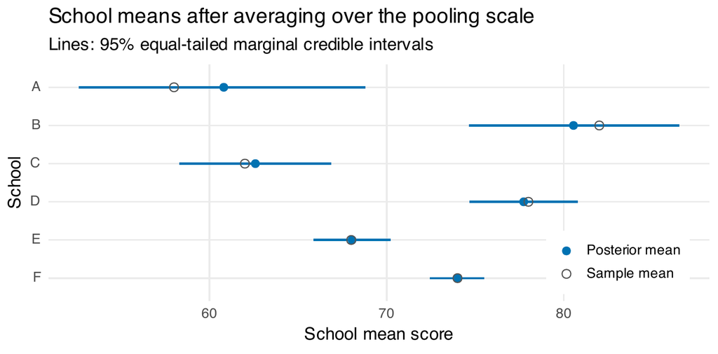

Earlier lecture notes, Section 3.3. This figure uses the six constructed schools in the companion.

Intervals describe uncertainty about school means, not the spread of individual student scores. School A moves toward the shared center more than school F.

## 4. Joint posterior draws and prediction

Each row uses one scale and one shared center for all schools. This preserves dependence for joint comparisons and rankings. The grid inverse CDF is a numerical approximation; conditional normal sampling is exact. With fresh randomness across rows there is no Markov-chain burn-in or mixing problem.

```r
set.seed(33022); S <- 100000
keep <- !duplicated(g$cdf)
tau <- approx(g$cdf[keep], g$tau[keep],
              xout=runif(S), rule=2)$y
p <- school_means_conditional(tau, y, s2, m0, v0)
eta <- rnorm(S, p$m, sqrt(p$v))
theta <- p$w*matrix(rep(y, each=S), nrow=S) +
  (1-p$w)*eta + matrix(rnorm(S*J), S)*sqrt(p$d)
newmean <- rnorm(S, eta, tau)
newstudent <- rnorm(S, newmean, sqrt(sigma2))
in_A <- rnorm(S, theta[,1], sqrt(sigma2))
joint <- mean(theta[,2]-theta[,1] > 5 &
              theta[,4]-theta[,3] > 5)
mcse <- sqrt(joint*(1-joint)/S)
best <- tabulate(max.col(theta), nbins=J)/S
c(joint=joint, MCSE=mcse)
```

```
##        joint         MCSE
## 0.9981900000 0.0001344144
```

```r
best  # posterior probability each school has the largest mean
```

```
## [1] 0.00000 0.79743 0.00000 0.20203 0.00000 0.00054
```

```r
c(existing_student=sd(in_A), new_school=sd(newmean),
  new_school_student=sd(newstudent))
```

```
##   existing_student         new_school new_school_student
##          10.829875           9.768558          13.953752
```

With seed 33022 and 100,000 draws, the joint contrast probability is 0.99819 with Monte Carlo standard error about 0.000134. Predictive standard deviations are approximately 10.8 for a student in school A, 9.8 for a new school’s mean, and 14.0 for a student in that new school. These are three distinct targets.

Plot the three simulated predictive distributions on a common score axis. Each curve corresponds to a different prediction target.

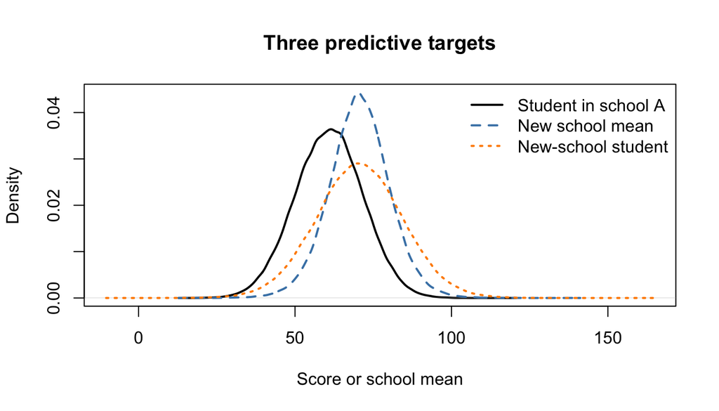

```r
curves <- list(density(in_A), density(newmean), density(newstudent))
plot(curves[[1]], xlim=range(vapply(curves, function(d) range(d$x),
                                  numeric(2))),
     ylim=c(0,max(vapply(curves, function(d) max(d$y), numeric(1)))),
     xlab="Score or school mean", main="Three predictive targets", lwd=2)
lines(curves[[2]], col="steelblue", lwd=2, lty=2)
lines(curves[[3]], col="darkorange", lwd=2, lty=3)
legend("topright", c("Student in school A", "New school mean", "New-school student"),
       col=c("black","steelblue","darkorange"), lty=1:3, lwd=2, bty="n")
```

## 5. Prior sensitivity: an extension to try

Repeat the grid, summaries, and simulation with inverse-gamma scale 50 and 800, keeping the shape at 3. Then try a half-normal prior on the between-school standard deviation with scale 10. For each alternative, use the resulting grid in place of `g` and repeat the numerical checks with the corresponding log prior.

```r
grid_ig50 <- school_means_grid(y, s2, m0, v0,
                               function(tau) log_prior(tau, scale = 50))
grid_ig800 <- school_means_grid(y, s2, m0, v0,
                                function(tau) log_prior(tau, scale = 800))
half_normal <- function(tau) log(2) + dnorm(tau, sd = 10, log = TRUE)
grid_half_normal <- school_means_grid(y, s2, m0, v0, half_normal)
```

Compare school A’s interval, the scale posterior, and the three predictive distributions. Increasing the draw count reduces Monte Carlo error. The comparison across priors measures sensitivity to the model specification.

# Section 3.4 — Gaussian geometry and exact simulation

**Concept.** A covariance factor maps independent standard normals to correlated normals. Its inverse maps a Gaussian probability ellipse to a circle.

**Example.** Generate a bivariate Gaussian with $\boldsymbol\mu=(1,-1)^\top$ and $\Sigma=\begin{pmatrix}4&2\\2&2\end{pmatrix}$. R’s `chol` returns the **upper** factor, so a column-vector implementation uses its transpose. With draws stored as rows, right multiplication by the upper factor gives the same transformation.

```r
set.seed(3405)
r <- 50000L
mu <- c(1, -1)
Sigma <- matrix(c(4, 2, 2, 2), 2, 2)
upper <- chol(Sigma)
z <- matrix(rnorm(2 * r), ncol=2)
y <- sweep(z %*% upper, 2, mu, "+")
stopifnot(isTRUE(all.equal(crossprod(upper), Sigma)))
mean_check <- cbind(estimate=colMeans(y), target=mu,
                   MCSE=sqrt(diag(Sigma) / r))
mean_check
```

```
##        estimate target        MCSE
## [1,]  0.9837288      1 0.008944272
## [2,] -1.0148915     -1 0.006324555
```

```r
cov(y)
```

```
##          [,1]     [,2]
## [1,] 3.960228 1.969840
## [2,] 1.969840 1.981016
```

Whitening should recover the original independent inputs. The target probability inside the 95% ellipse is 0.95; the coverage standard error is $\sqrt{0.95(0.05)/r}$.

```r
centered <- sweep(y, 2, mu, "-")
white <- t(forwardsolve(t(upper), t(centered)))
stopifnot(max(abs(white-z)) < 1e-10)
d2 <- rowSums(white^2)
c(coverage=mean(d2 <= qchisq(.95, 2)), target=.95,
  MCSE=sqrt(.95*.05/r))
```

```
##     coverage       target         MCSE
## 0.9506600000 0.9500000000 0.0009746794
```

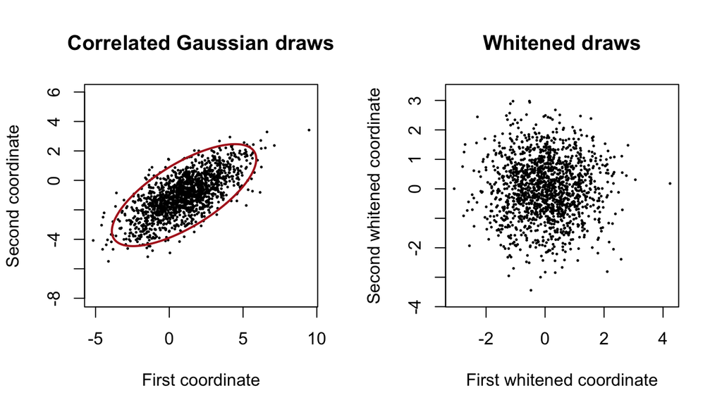

```r
par(mfrow=c(1,2))
plot(y[1:1500,], asp=1, pch=16, cex=.35,
     xlab="First coordinate", ylab="Second coordinate",
     main="Correlated Gaussian draws")
angle <- seq(0, 2*pi, length.out=300)
ellipse <- sqrt(qchisq(.95,2)) * cbind(cos(angle),sin(angle)) %*% upper
ellipse <- sweep(ellipse,2,mu,"+")
lines(ellipse,col="firebrick",lwd=2)
plot(white[1:1500,], asp=1, pch=16, cex=.35,
     xlab="First whitened coordinate", ylab="Second whitened coordinate",
     main="Whitened draws")
```

```r
par(mfrow=c(1,1))
```

The transformation reproduces the off-diagonal covariance as well as the marginal variances. **Extension:** replace the off-diagonal covariance by zero while holding both variances fixed. Compare ellipse orientation and the variance of the difference between coordinates.

# Section 3.5 — Scatter and joint covariance inference

**Concept.** The normal–inverse-Wishart update uses centered scatter and a separate contribution from disagreement between the prior and sample centers. Joint posterior draws then propagate covariance uncertainty.

## Printed data and conjugate update

**Example.** Use the three paired measurements from the lecture notes, with both coordinates measured in the same arbitrary units.

| Unit | First measurement | Second measurement |
| --- | --- | --- |
| 1 | 0 | 0 |
| 2 | 2 | 0 |
| 3 | 1 | 2 |

Use $\boldsymbol\mu\mid\Sigma\sim N_2(\mathbf m_0,\Sigma/k_0)$ and $\Sigma\sim\operatorname{IW}_2(d_0,\mathbf s_0)$, with $\mathbf m_0=\mathbf0$, $k_0=1$, $d_0=5$, $\mathbf s_0=2\mathbf I_2$. The inverse-Wishart density is proportional to $|\Sigma|^{-(d_0+p+1)/2}\exp[-\operatorname{tr}(\mathbf s_0\Sigma^{-1})/2]$.

Center the observations before calculating the scatter matrix. Add the displacement outer product and use the updated scale to compute the covariance mean for comparison with simulation.

```r
x <- rbind(c(0,0),c(2,0),c(1,2))
n <- nrow(x)
p <- ncol(x)
xbar <- colMeans(x)
scatter <- crossprod(sweep(x,2,xbar,"-"))
m0 <- c(0,0); k0 <- 1; d0 <- 5; s0 <- 2*diag(p)
kn <- k0+n
mn <- (k0*m0+n*xbar)/kn
dn <- d0+n
sn <- s0+scatter+(k0*n/kn)*tcrossprod(xbar-m0)
list(mean=xbar, centered_scatter=scatter, known_zero_scatter=crossprod(x),
     k_n=kn, m_n=mn, d_n=dn, s_n=sn)
```

```
## $mean
## [1] 1.0000000 0.6666667
##
## $centered_scatter
##      [,1]     [,2]
## [1,]    2 0.000000
## [2,]    0 2.666667
##
## $known_zero_scatter
##      [,1] [,2]
## [1,]    5    2
## [2,]    2    4
##
## $k_n
## [1] 4
##
## $m_n
## [1] 0.75 0.50
##
## $d_n
## [1] 8
##
## $s_n
##      [,1] [,2]
## [1,] 4.75  0.5
## [2,] 0.50  5.0
```

```r
stopifnot(isTRUE(all.equal(sn, matrix(c(4.75,.5,.5,5),2,2))))
Sigma_mean <- sn/(dn-p-1)
mu_cov <- Sigma_mean/kn
predictive_cov <- (1+1/kn)*Sigma_mean
list(covariance_mean=Sigma_mean, mean_vector_covariance=mu_cov,
     predictive_covariance=predictive_cov)
```

```
## $covariance_mean
##      [,1] [,2]
## [1,] 0.95  0.1
## [2,] 0.10  1.0
##
## $mean_vector_covariance
##        [,1]  [,2]
## [1,] 0.2375 0.025
## [2,] 0.0250 0.250
##
## $predictive_covariance
##        [,1]  [,2]
## [1,] 1.1875 0.125
## [2,] 0.1250 1.250
```

The centered cross-product is zero, but disagreement between the prior and sample means contributes 0.5 to the posterior scale’s off-diagonal entries. The analytic covariance mean is $\begin{pmatrix}.95&.1\\.1&1\end{pmatrix}$; the mean-vector covariance is one quarter of this matrix, and the predictive covariance is 1.25 times this matrix.

## Direction of prior–data disagreement

The extra scale is a positive semidefinite outer product; individual cross-products can still be negative. For this dataset it increases the posterior scale only along the displacement from the prior mean.

```r
delta <- xbar-m0
disagreement <- (k0*n/kn)*tcrossprod(delta)
u <- delta/sqrt(sum(delta^2))
v <- c(-u[2],u[1])
directional_scale <- c(along=drop(t(u)%*%disagreement%*%u),
                       perpendicular=drop(t(v)%*%disagreement%*%v))
list(disagreement=disagreement, directional_scale=directional_scale)
```

```
## $disagreement
##      [,1]      [,2]
## [1,] 0.75 0.5000000
## [2,] 0.50 0.3333333
##
## $directional_scale
##         along perpendicular
##  1.083333e+00  2.585758e-18
```

```r
stopifnot(abs(directional_scale["perpendicular"])<1e-12,
          min(eigen(disagreement,symmetric=TRUE)$values)>-1e-12)
```

The added directional scales are $13/12$ along the displacement and zero perpendicular to it. Dividing by $d_n-p-1=5$ gives its contribution to the posterior mean covariance. This is a statement about scale, not a complete description of posterior uncertainty about the covariance matrix.

## Wishart construction and independent NIW draws

The explicit Wishart construction applies to integer degrees of freedom. `rWishart`, used for the larger simulation below, accepts noninteger degrees of freedom at least as large as the dimension. The mathematical positive definite Wishart law also exists for $p-1<d<p$, but this R function does not cover that range. The posterior below has $d_n=8$ and $p=2$.

```r
set.seed(3505)
Psi <- matrix(c(1,.5,.5,2),2,2)
construct_wishart <- function(df, scale) {
  stopifnot(df >= 0, df == as.integer(df))
  z <- matrix(rnorm(df*nrow(scale)), nrow=df, ncol=nrow(scale))
  crossprod(z %*% chol(scale))
}
one_df <- construct_wishart(1,Psi)
four_df <- construct_wishart(4,Psi)
list(rank_one=qr(one_df)$rank, rank_four=qr(four_df)$rank,
     expected_one=Psi, expected_four=4*Psi)
```

```
## $rank_one
## [1] 1
##
## $rank_four
## [1] 2
##
## $expected_one
##      [,1] [,2]
## [1,]  1.0  0.5
## [2,]  0.5  2.0
##
## $expected_four
##      [,1] [,2]
## [1,]    4    2
## [2,]    2    8
```

The NIW algorithm first draws precision, inverts it to obtain the covariance, then draws the mean conditional on that **same** covariance. A predictive draw uses both parameters from the same repetition.

```r
r <- 50000L
precision <- rWishart(r, df=dn, Sigma=solve(sn))
Sigma_draws <- array(NA_real_,c(p,p,r))
mu_draws <- predictive <- matrix(NA_real_,r,p)
for (s in seq_len(r)) {
  Sigma_s <- solve(precision[,,s])
  lower_s <- t(chol(Sigma_s))
  mu_s <- mn+drop(lower_s %*% rnorm(p))/sqrt(kn)
  Sigma_draws[,,s] <- Sigma_s
  mu_draws[s,] <- mu_s
  predictive[s,] <- mu_s+drop(lower_s %*% rnorm(p))
}
Sigma_est <- apply(Sigma_draws,c(1,2),mean)
Sigma_se <- apply(Sigma_draws,c(1,2),sd)/sqrt(r)
list(covariance_mean=Sigma_est, covariance_mean_MCSE=Sigma_se,
     mean_vector_mean=colMeans(mu_draws),
     mean_vector_covariance=cov(mu_draws),
     predictive_covariance=cov(predictive))
```

```
## $covariance_mean
##           [,1]      [,2]
## [1,] 0.9508117 0.1005886
## [2,] 0.1005886 0.9943278
##
## $covariance_mean_MCSE
##             [,1]        [,2]
## [1,] 0.003625653 0.002232173
## [2,] 0.002232173 0.003531985
##
## $mean_vector_mean
## [1] 0.7503426 0.5008456
##
## $mean_vector_covariance
##            [,1]       [,2]
## [1,] 0.23575713 0.02405269
## [2,] 0.02405269 0.24527128
##
## $predictive_covariance
##           [,1]      [,2]
## [1,] 1.1903894 0.1141054
## [2,] 0.1141054 1.2244790
```

```r
# Check the analytic covariance-entry means on a Monte Carlo scale.
stopifnot(all(abs(Sigma_est-Sigma_mean) < 6*Sigma_se))
```

Compare the displayed Monte Carlo estimates with the analytic matrices above; finite simulation error remains. The iid standard errors apply to the averaged covariance entries. They are not automatically standard errors for all derived nonlinear summaries.

Compute the variance in the direction $(1,-1)$ in two ways. Average the conditional variance over covariance draws, then compare with the sample variance of the drawn contrasts.

```r
contrast_variance <- (Sigma_draws[1,1,]+Sigma_draws[2,2,]-
                       2*Sigma_draws[1,2,])/kn
c(conditional_variances_average=mean(contrast_variance),
  empirical_contrast_variance=var(mu_draws[,1]-mu_draws[,2]),
  target=drop(c(1,-1) %*% mu_cov %*% c(1,-1)))
```

```
## conditional_variances_average   empirical_contrast_variance
##                     0.4359906                     0.4329230
##                        target
##                     0.4375000
```

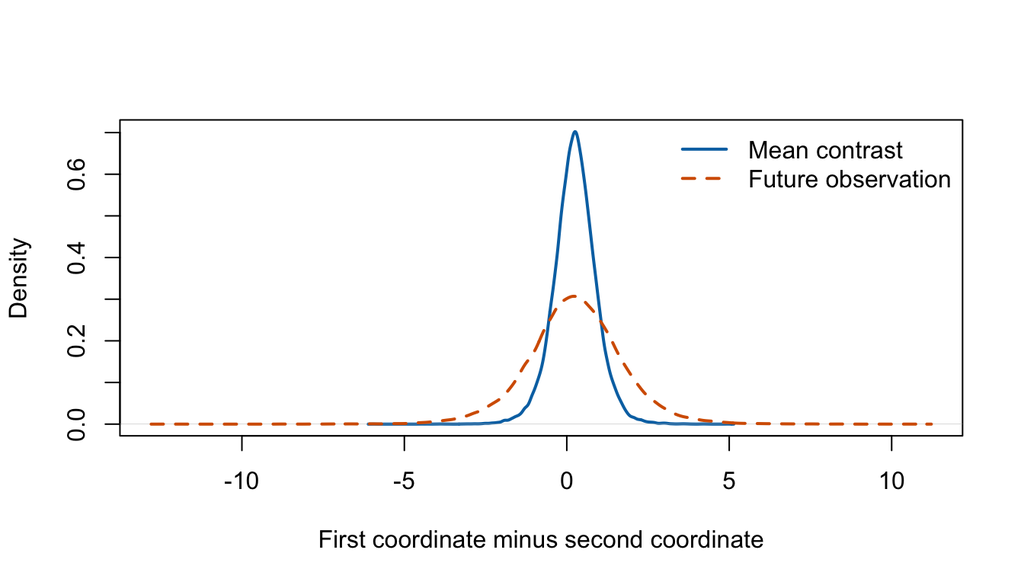

```r
contrast_draw <- mu_draws[, 1] - mu_draws[, 2]
predictive_contrast <- predictive[, 1] - predictive[, 2]
contrast_density <- density(contrast_draw)
predictive_density <- density(predictive_contrast)
plot(contrast_density, type = "l", col = "#0072B2", lwd = 2, main = "",
     xlim = range(contrast_density$x, predictive_density$x),
     xlab = "First coordinate minus second coordinate", ylab = "Density")
lines(predictive_density, col = "#D55E00", lty = 2, lwd = 2)
legend("topright", c("Mean contrast", "Future observation"), bty = "n",
       col = c("#0072B2", "#D55E00"), lwd = 2, lty = c(1, 2))
```

**Extension:** change $k_0$ from 1 to 4 and rerun the update and simulation. Explain how the between-center contribution changes, not just the posterior mean. Then replace covariance draws by the fixed matrix $E(\Sigma\mid\mathbf x^n)$ when generating means. Matching a covariance matrix does not establish that the joint posterior or its tail probabilities have been reproduced.

## Bivariate LKJ calibration

**Concept.** In two dimensions the LKJ shape controls prior concentration of the correlation around zero.

**Example.** Compare shapes one and two at a correlation threshold of 0.8. Under the transformation $(\rho+1)/2$, the two priors are symmetric Beta distributions. Use one Beta tail and double it to get the probability of $|\rho|>0.8$.

```r
lkj_shapes <- c(1, 2)
lkj_tails <- 2 * pbeta((1 - 0.8) / 2, lkj_shapes, lkj_shapes)
stopifnot(max(abs(lkj_tails - c(.2, .056))) < 1e-12)
data.frame(h0 = lkj_shapes, probability_above_0.8 = lkj_tails)
```

```
##   h0 probability_above_0.8
## 1  1                 0.200
## 2  2                 0.056
```

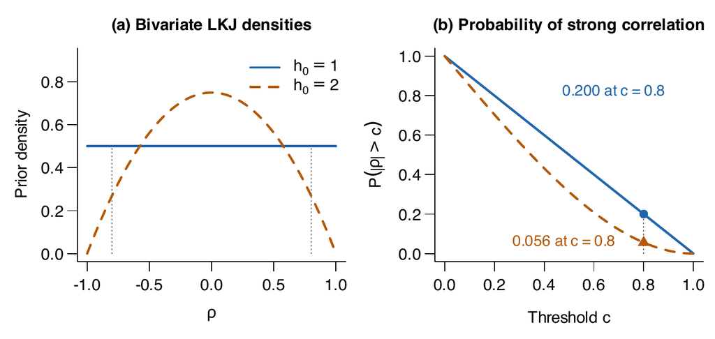

Lecture notes, Section 3.5. The right panel shows the tail probabilities calculated above.

These calculations are specific to $p=2$. Uniformity over a larger space of correlation matrices does not make each marginal correlation uniform. **Extension:** select a shape $h_0$ so that $P(|\rho|>0.8)=0.1$ by solving `2*pbeta(.1,h0,h0)-.1=0` with `uniroot` on `[1,2]`.

R 4.6.0 · BayesComp 0.1.0